# A summary of SciComm tweets at ESA 2017 (#ESASciComm)

E.J. Rollinson

## About this document

This document was produced by [Emily J. Rollinson](http://rollinsonecology.com) (ejrollinson on Twitter).

The code generating this document was originally developed by [Francois Michonneau](https://github.com/fmichonneau) (fmic_ on Twitter) for the 2015 Evolution meeting and can be found [here](https://github.com/fmichonneau/evol2015-tweets).

It has since been [adapted](https://github.com/jlehtoma/iccb2015-tweets/blob/gh-pages/index.Rmd) for ICCB-ECCB 2015 by Joona Lehtomaki (jlehtoma on Twitter).

Thanks also to Emily Sessa (ebsessa on Twitter) for reproducing this code for the 2015 Botany meeting, bringing it to my attention.

I originally adapted this code for the 2015 Ecological Society of America meeting (#ESA100) in Baltimore, MD, and have since reproduced it for [subsequent ESA and Botany meetings](https://erollinson.github.io/).

Tweets using the hashtag #ESASciComm were aggregated from Twitter using the R package [twitteR](https://cran.r-project.org/web/packages/twitteR/index.html) and the Twitter API. The aggregated tweets are [available on Figshare](https://figshare.com/articles/Tweets_using_ESA2017_hashtag/5306302).

This document was generated using RMarkdown, and the source is [available on GitHub](https://github.com/erollinson/erollinson.github.io).

This document (and associated code) is released under a CC0 licence.

## Basic summary

Of the 189 tweets tagged #ESASciComm as of 12:30 PM EST 8/13/2017:

[output not shown]

## The 5 most favorited tweets

> I’m a terrible artist, but maybe I get some points for trying?! #esascicomm #sketchyourscience https://t.co/ZUQel16kQp

> — duffy_ma | [2017-08-10](https://twitter.com/duffy_ma/status/895777287387324416) | 0 retweets, 50 favorites.

> Here it is with more info added thanks to feedback from @commnatural! #esascicomm #esa2017 #sketchyourscience https://t.co/htQ5Jx4agp

> — duffy_ma | [2017-08-10](https://twitter.com/duffy_ma/status/895780056093425664) | 2 retweets, 20 favorites.

> #ESA2017 #improv was FUN!! I hope is was useful too. @hormiga @cjlortie #ESASciComm #SciComm 1/ https://t.co/MrEMuvqSCr

> — A_Hettinger | [2017-08-07](https://twitter.com/A_Hettinger/status/894641661531181056) | 4 retweets, 17 favorites.

> Hey #ESA2017! We’re excited for you to #sketchyourscience at our @ESA_org #ESASciComm booth. #sciart #scicomm https://t.co/y1kOAcZv0O

> — A_Hettinger | [2017-08-04](https://twitter.com/A_Hettinger/status/893590421133066240) | 3 retweets, 16 favorites.

> MANY brave & lively folks @ #ESA2017 Improv!! #ESASciComm #SciComm https://t.co/dftXS2XFee

> — A_Hettinger | [2017-08-07](https://twitter.com/A_Hettinger/status/894621874189094912) | 3 retweets, 14 favorites.

## The 5 most retweeted tweets

> Check out our piece about the #MySciComm blog series! https://t.co/CvyTkC8CCJ #ESASciComm Section, #ESA2017 https://t.co/Sdhd22YXrR

> — A_Hettinger | [2017-08-08](https://twitter.com/A_Hettinger/status/894915767489011712) | 10 retweets, 11 favorites.

> #ESASciComm booth looking good thanks to all the #sketchyourscience contributions. #ESA2017 #SciArt #SciComm https://t.co/EIBJSPys3a

> — A_Hettinger | [2017-08-10](https://twitter.com/A_Hettinger/status/895793910533898240) | 7 retweets, 13 favorites.

> #ESA2017, get ur tix to @b4theabstract @story_collider live show to see scientists tell their stories! https://t.co/8zOjVggb7O

> — A_Hettinger | [2017-08-06](https://twitter.com/A_Hettinger/status/894314486336602112) | 6 retweets, 5 favorites.

> Start your #ESA2017 w/ a FUN improv #SciComm wkshp! Mon 10:15 OCC-C123. Why improv?? See link. https://t.co/efU6diEQ98

> — A_Hettinger | [2017-08-04](https://twitter.com/A_Hettinger/status/893596814317768704) | 6 retweets, 9 favorites.

> Learn the ins & outs of #storytelling today @ 11:30 D140 #ESA2017 #SciComm #ESASciComm @b4theabstract https://t.co/2AmDKDQe7j

> — A_Hettinger | [2017-08-09](https://twitter.com/A_Hettinger/status/895293996058132480) | 4 retweets, 4 favorites.

## Top tweeters

All generated tweets (including retweets)

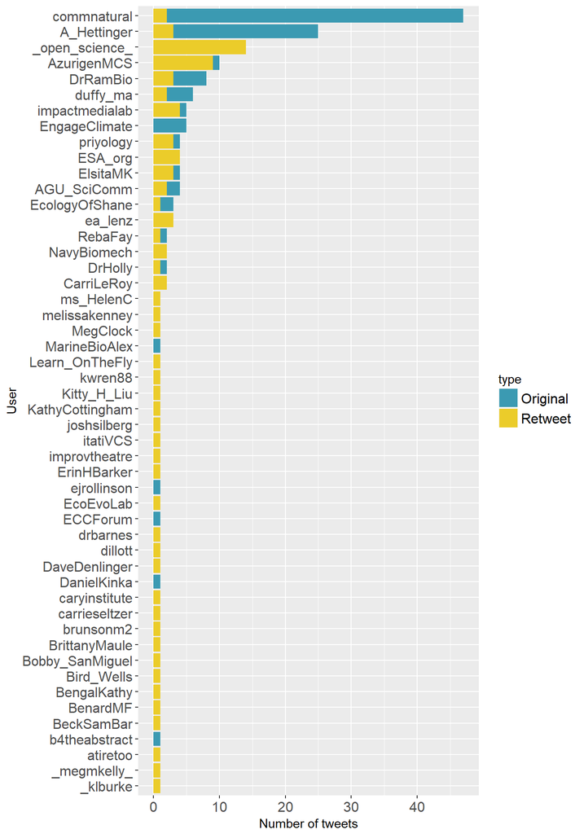

Only for original tweets (retweets excluded)

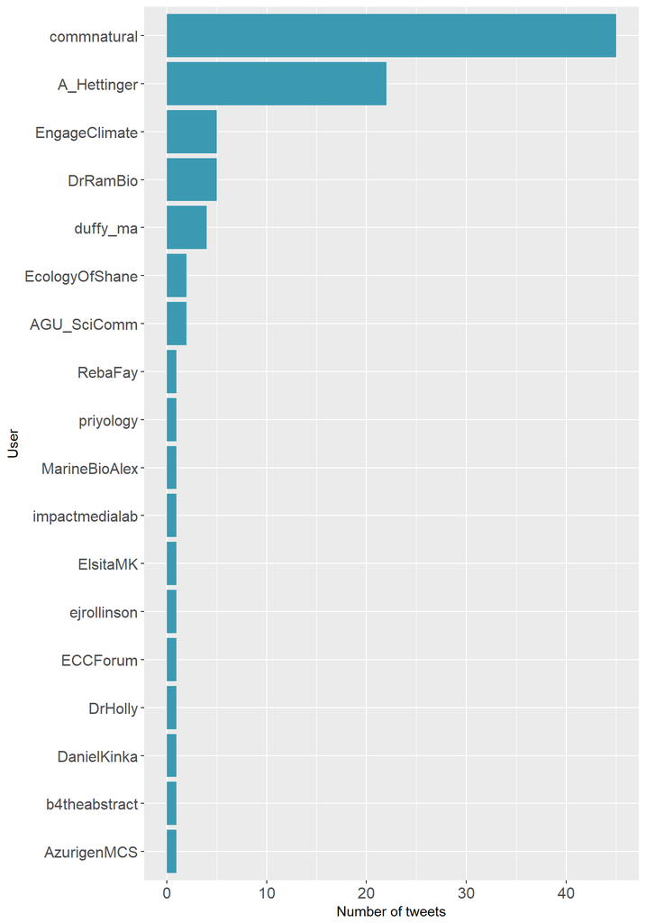

## Most favorited/retweeted users

The figures below only include users who tweeted 5+ times, and don’t include retweets.

### Number of favorites received by users

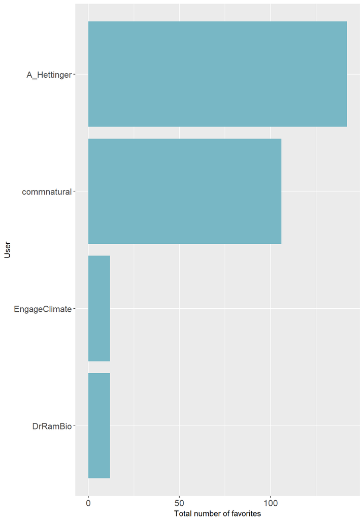

### Number of retweets received by users

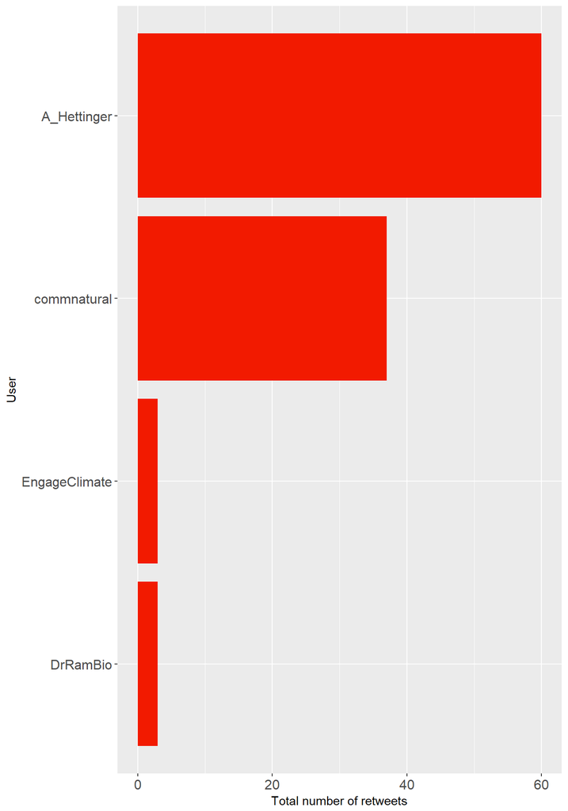

### Mean numbers of favorites received

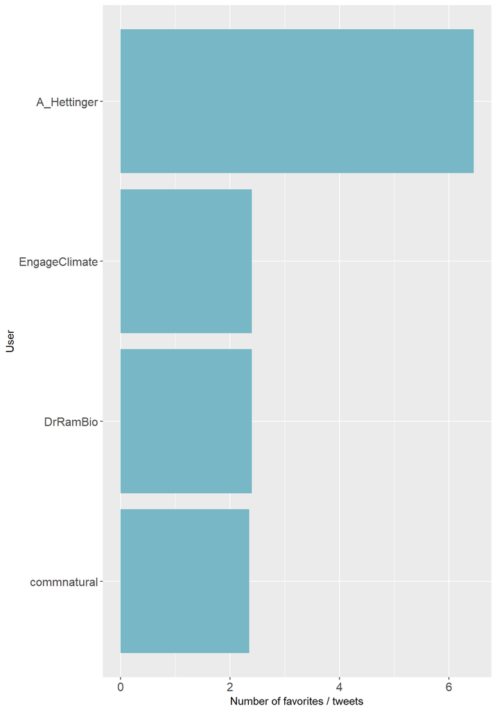

### Mean numbers of retweets received

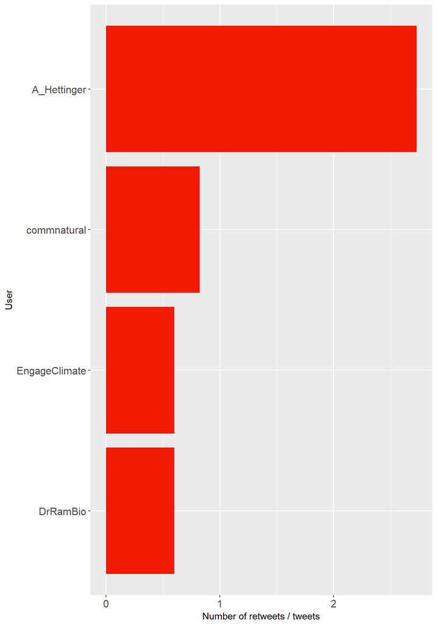

## Word cloud

The top 100 words among the original tweets (excludes RTs, hashtags, mentions, URLs, and “the’,”&“, etc.).

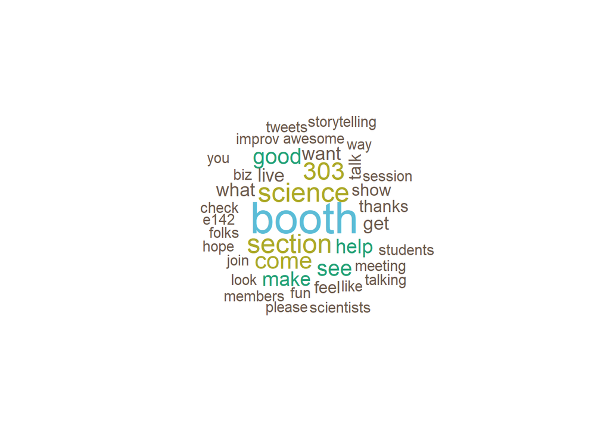

To the extent possible under law, [Emily J. Rollinson](https://github.com/erollinson/erollinson.github.io) has waived all copyright and related or neighboring rights to Summary of SciComm tweets at ESA 2017. This work is published from: United States.